# Puppy Small Dog Analysis

##### >>> Q25r6

**Q25r6: I wanted a puppy from a source that I trust - How important were each of the following in choosing your puppy?**

1896 non-empty/NA responses out of 1896 possible responses ( 100 %)

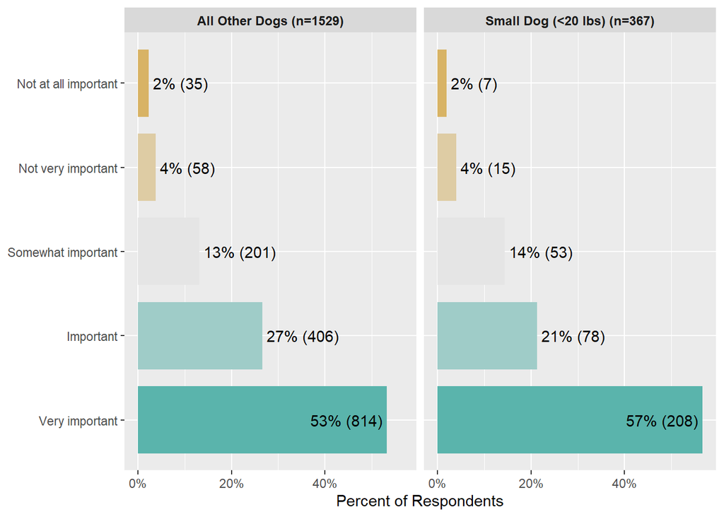

##### >>> Q25r7

**Q25r7: I wanted a puppy that was hypoallergenic - How important were each of the following in choosing your puppy?**

1896 non-empty/NA responses out of 1896 possible responses ( 100 %)

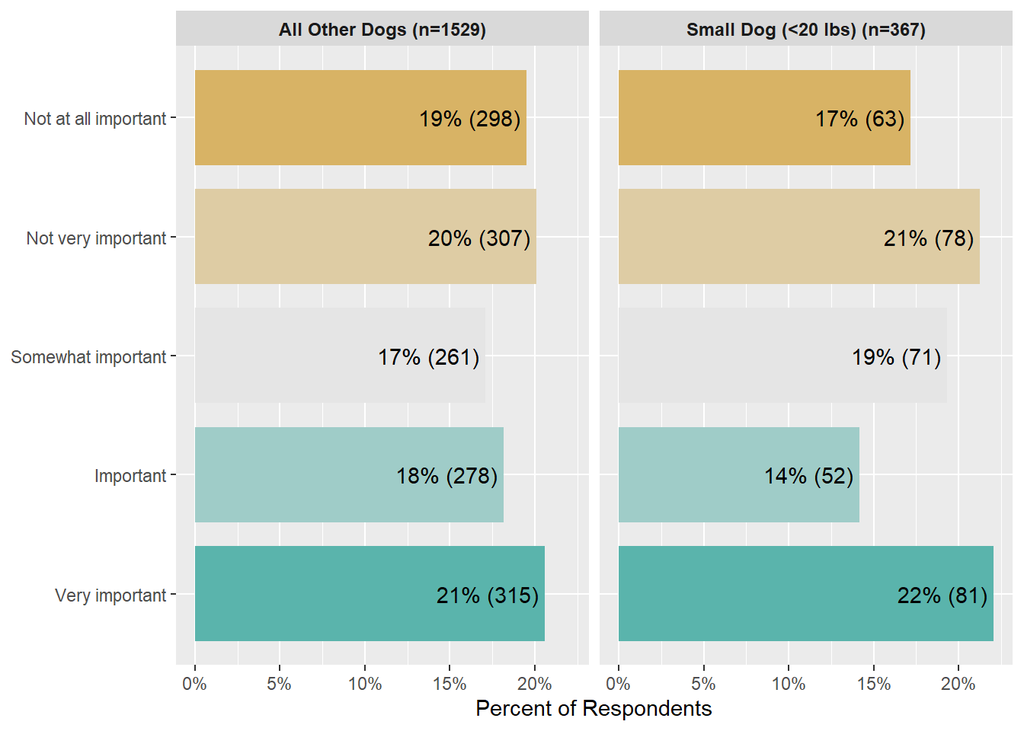

##### >>> Q25r8

**Q25r8: I wanted a puppy with a particular fur color (e.g., black, white, golden, brown, mixed, etc.) - How important were each of the following in choosing your puppy?**

1896 non-empty/NA responses out of 1896 possible responses ( 100 %)

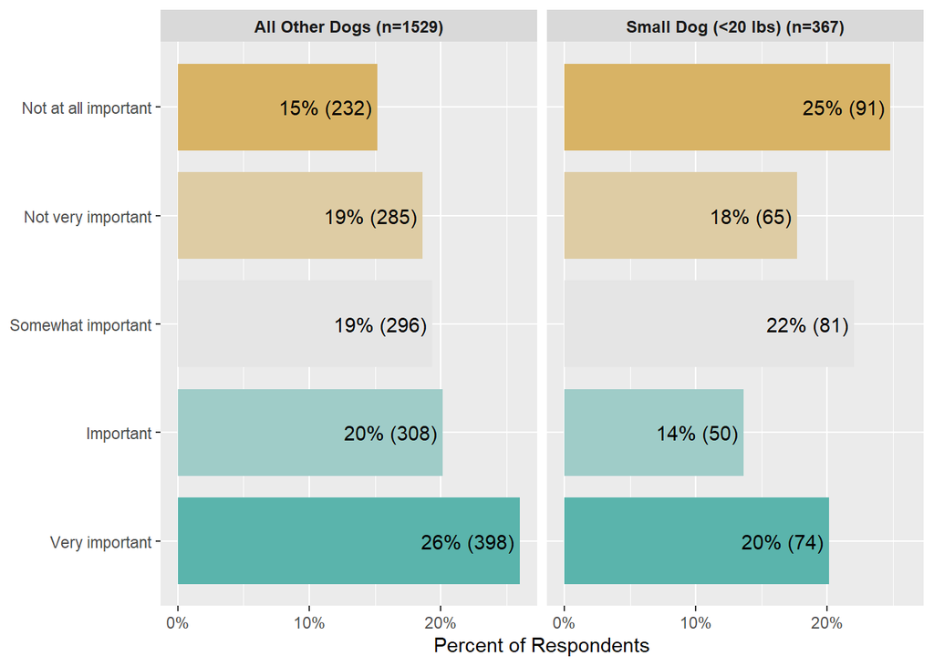

##### >>> Q26

**You shared that getting a particular breed or breed type was very important to you. Can you please share why this was important? Please choose up to 3 most important reasons.**

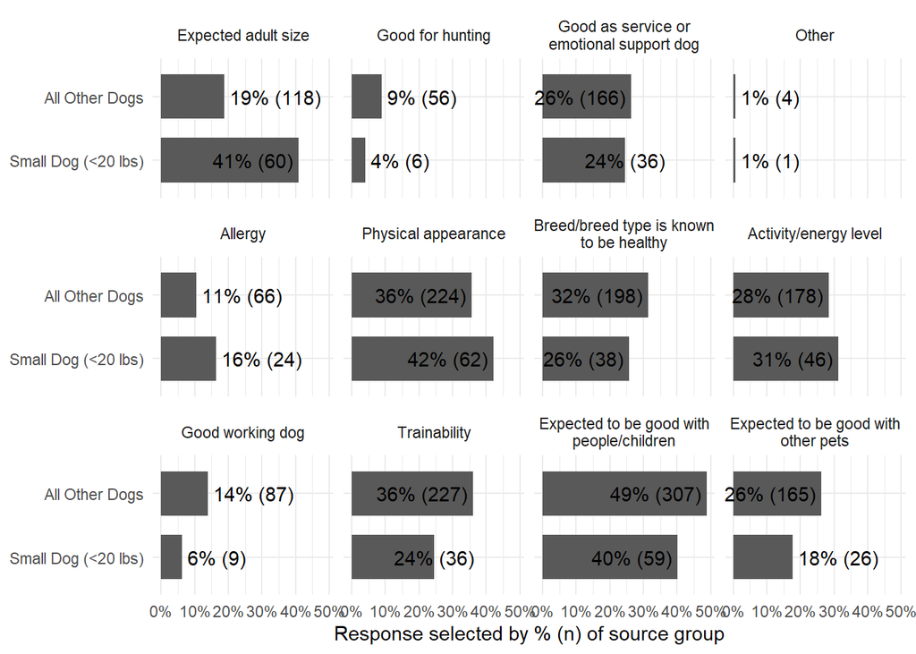

##### >>> Q27

**Q27: Have you owned this breed/breed type before?**

775 non-empty/NA responses out of 775 possible responses ( 100 %)

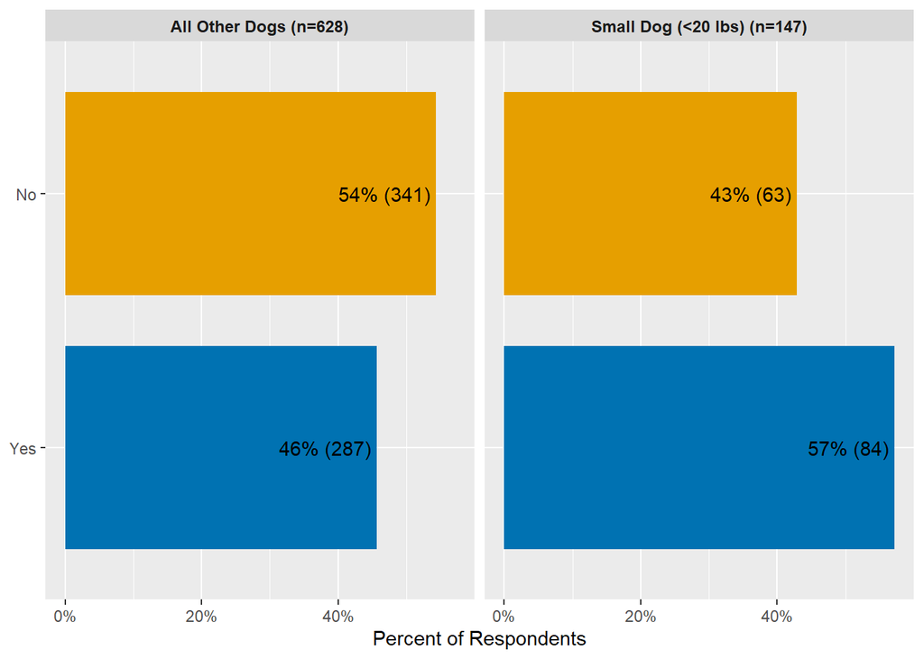

#### >> Q28

**How important were the following things in deciding where you got your puppy?**

1896 total non-empty/NA responses from 1896 possible respondents ( 100 %)

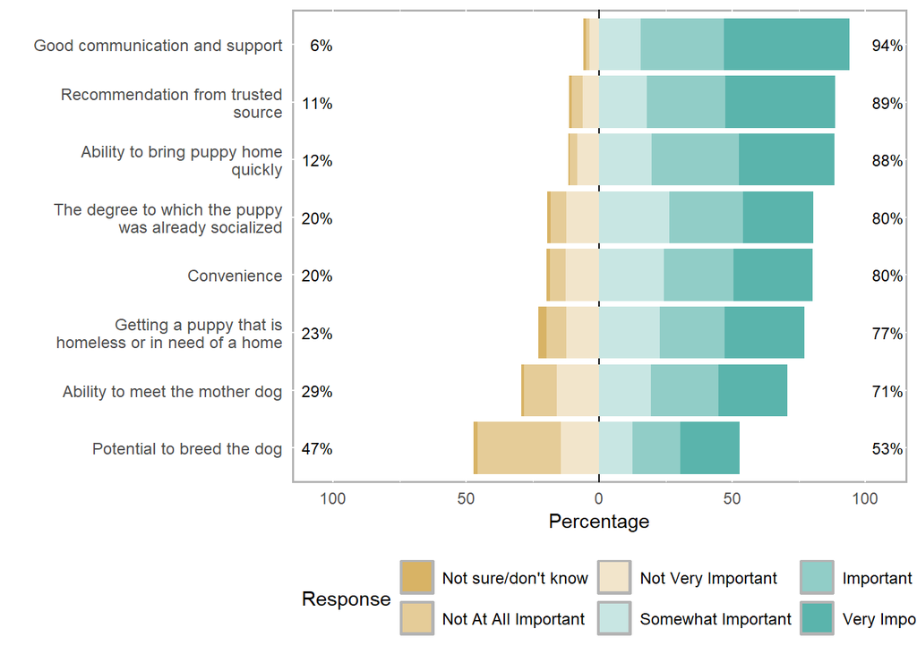

#### >> Q28

**Q28r1: Convenience - How important were the following things in deciding where you got your puppy?**

1896 non-empty/NA responses out of 1896 possible responses ( 100 %)

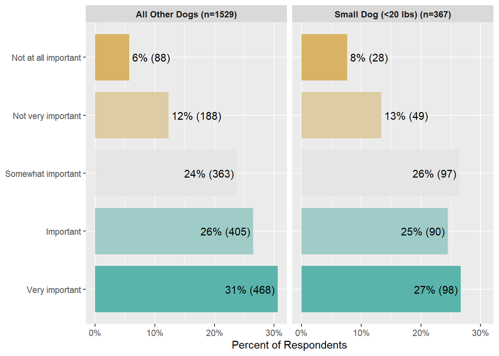

#### >> Q28r2

**Q28r2: The degree to which the puppy was already socialized - How important were the following things in deciding where you got your puppy?**

1896 non-empty/NA responses out of 1896 possible responses ( 100 %)

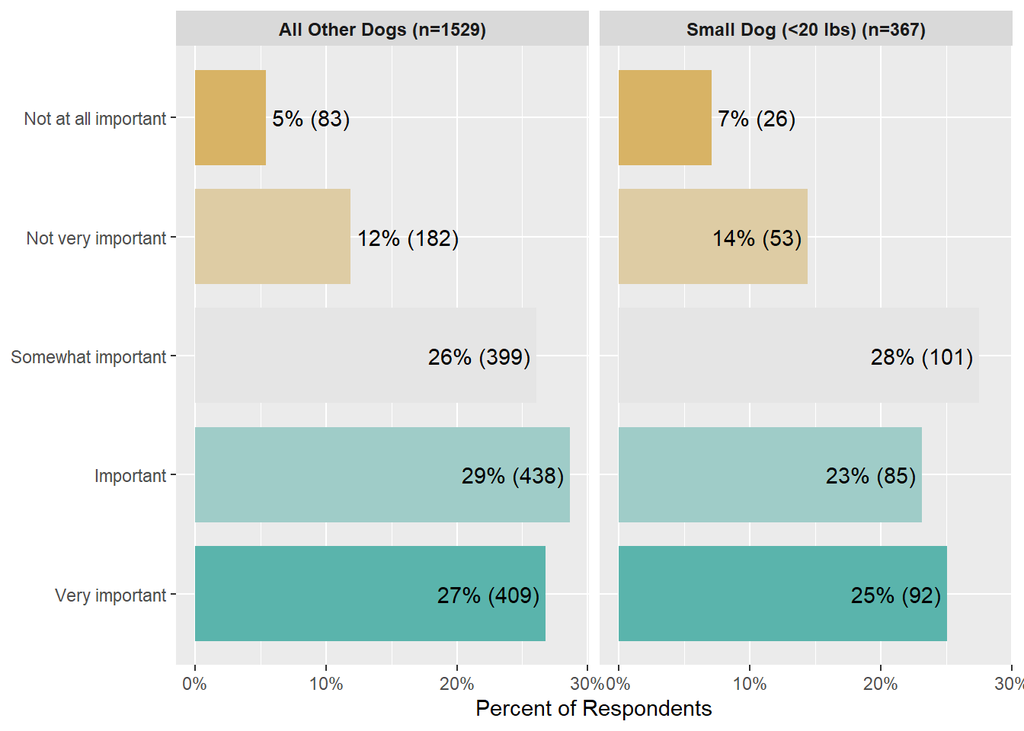

#### >> Q28r3

**Q28r3: Getting a puppy that is homeless or in need of a home - How important were the following things in deciding where you got your puppy?**

1896 non-empty/NA responses out of 1896 possible responses ( 100 %)

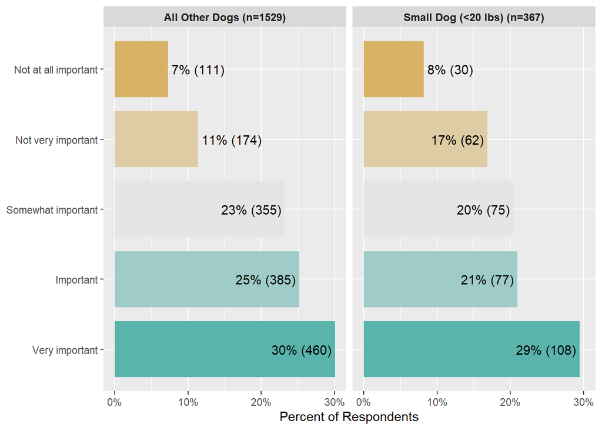

#### >> Q28r4

**Q28r4: Ability to bring puppy home quickly - How important were the following things in deciding where you got your puppy?**

1896 non-empty/NA responses out of 1896 possible responses ( 100 %)

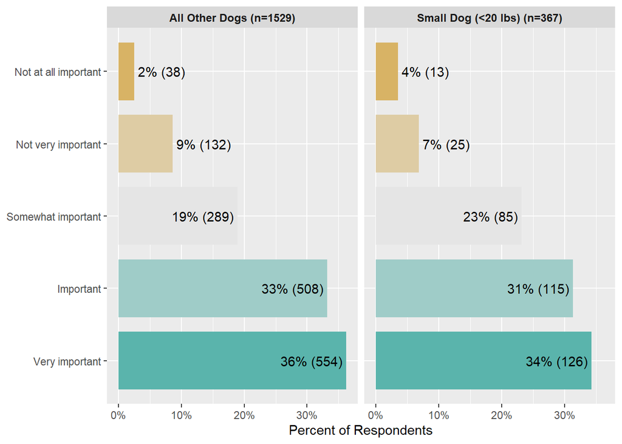

#### >> Q28r5

**Q28r5: Ability to meet the mother dog - How important were the following things in deciding where you got your puppy?**

1896 non-empty/NA responses out of 1896 possible responses ( 100 %)

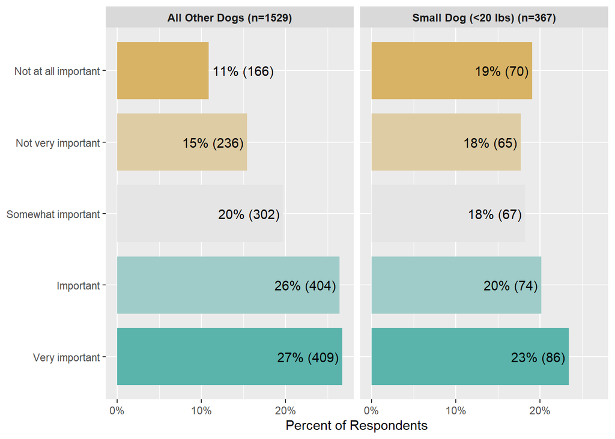

#### >> Q28r6

**Q28r6: Potential to breed the dog - How important were the following things in deciding where you got your puppy?**

1896 non-empty/NA responses out of 1896 possible responses ( 100 %)

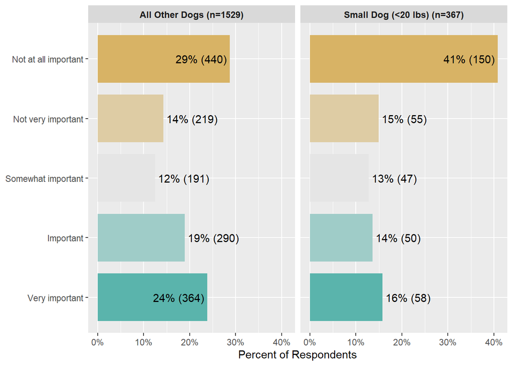

#### >> Q28r7

**Q28r7: Recommendation from trusted source - How important were the following things in deciding where you got your puppy?**

1896 non-empty/NA responses out of 1896 possible responses ( 100 %)

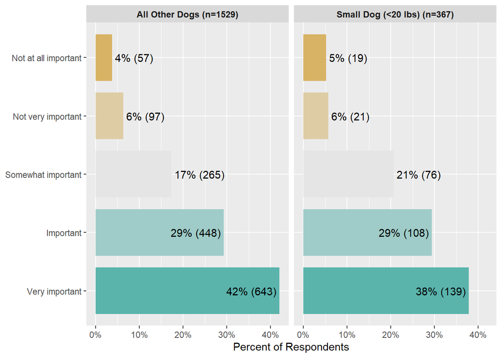

#### >> Q28r8

**Q28r8: Good communication and support - How important were the following things in deciding where you got your puppy?**

1896 non-empty/NA responses out of 1896 possible responses ( 100 %)

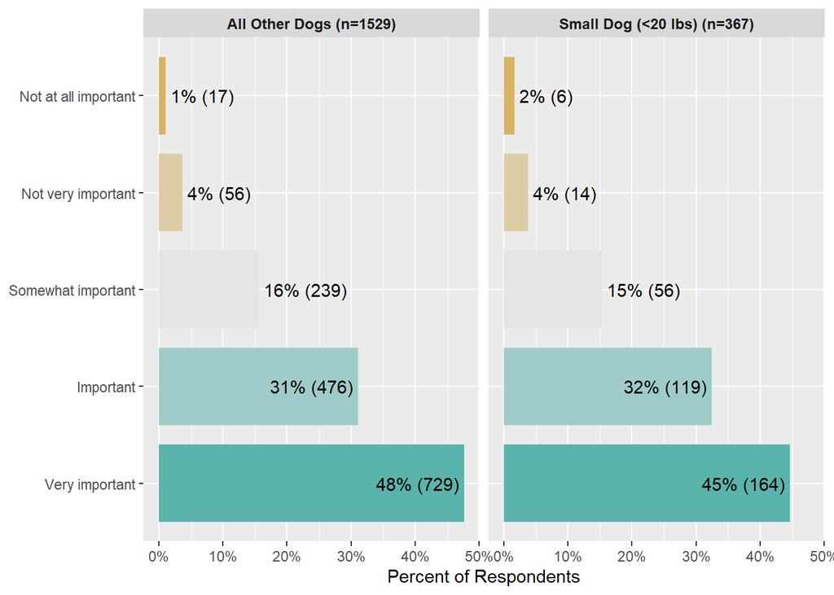

## Everyone - Willingness to pay

## Q29

**Q29: How much did you pay for your puppy?**

4002 non-empty/NA responses out of 4002 possible responses ( 100 %)

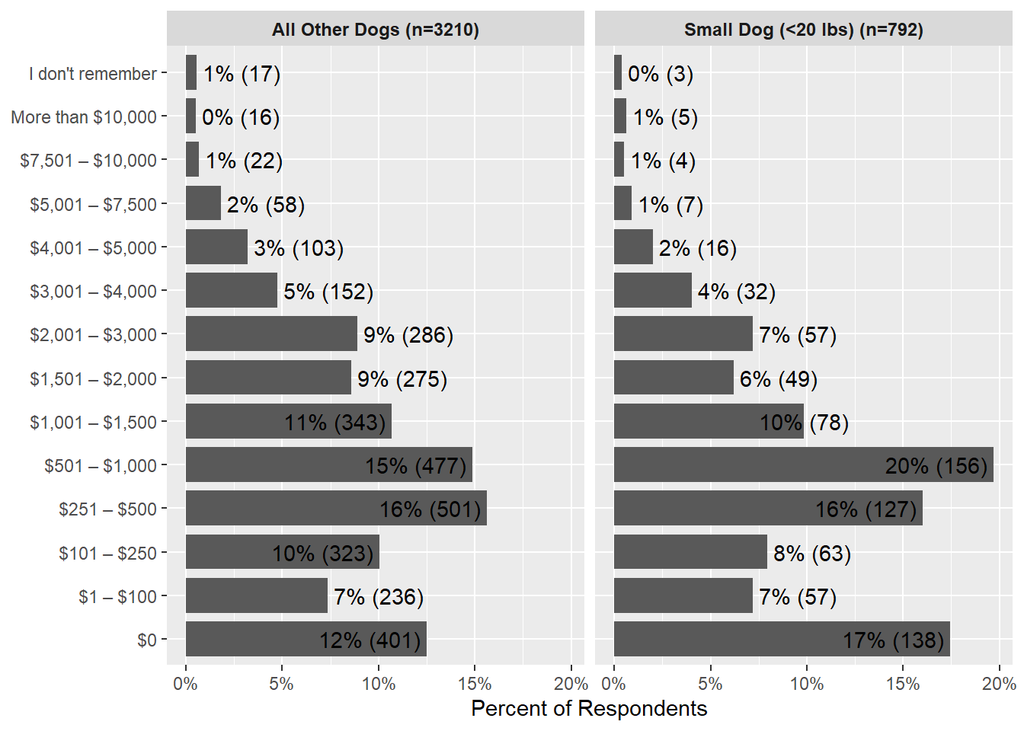

## Q30

**Were any of the following things included in what you paid for your puppy?**

[figure not shown]

## Q31

**Q31: Were you willing to pay more for a puppy than what you actually paid?**

4002 non-empty/NA responses out of 4002 possible responses ( 100 %)

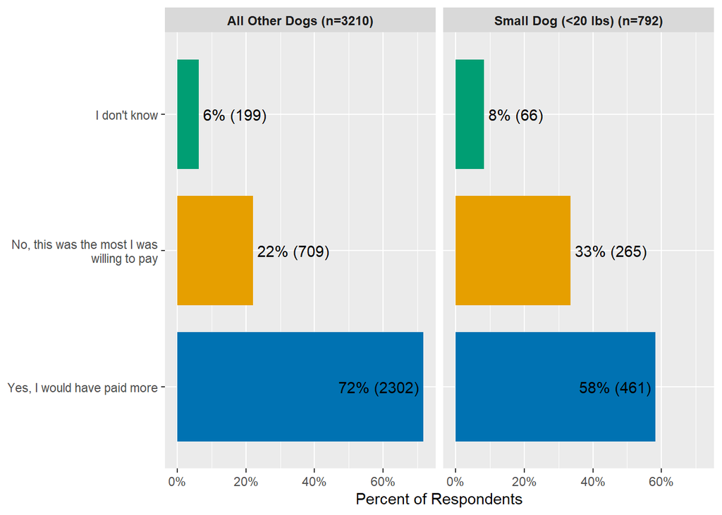

## Q32

**Q32: Did you place a deposit on your puppy at any point?**

4002 non-empty/NA responses out of 4002 possible responses ( 100 %)

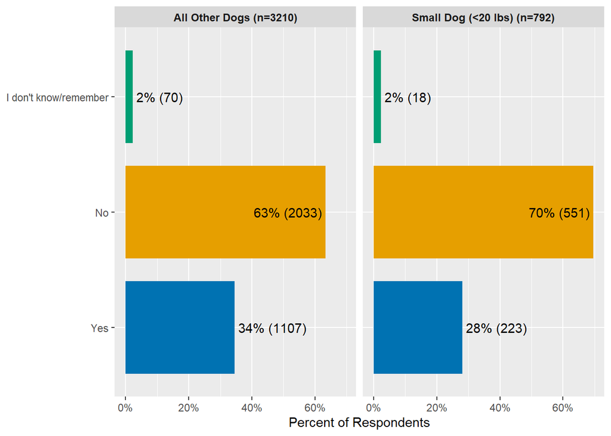

## Q33

**Q33: Was financing available where you got your puppy?**

4002 non-empty/NA responses out of 4002 possible responses ( 100 %)

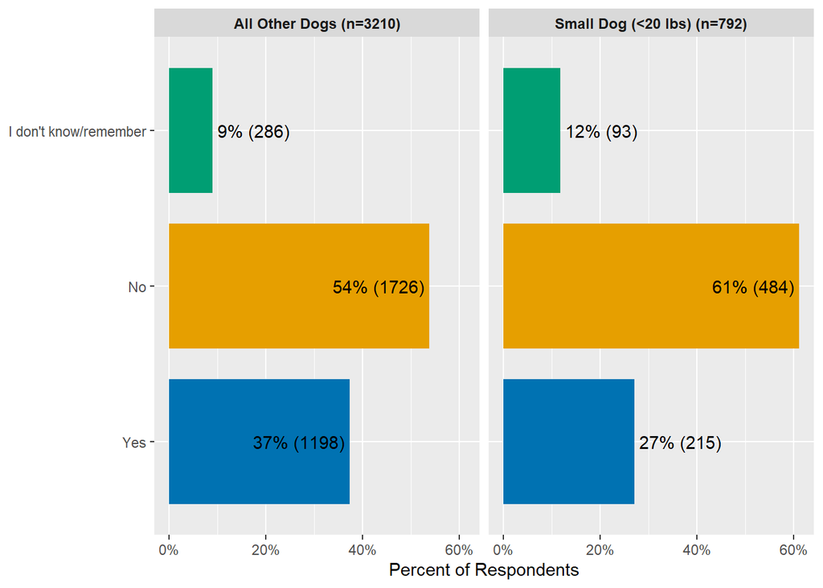

## Source of puppy

## Q34_new (…)

**(NEW CLASSIFICATION) Q34: Where did your puppy come from? Please select the best match.**

4002 non-empty/NA responses out of 4002 possible responses ( 100 %)

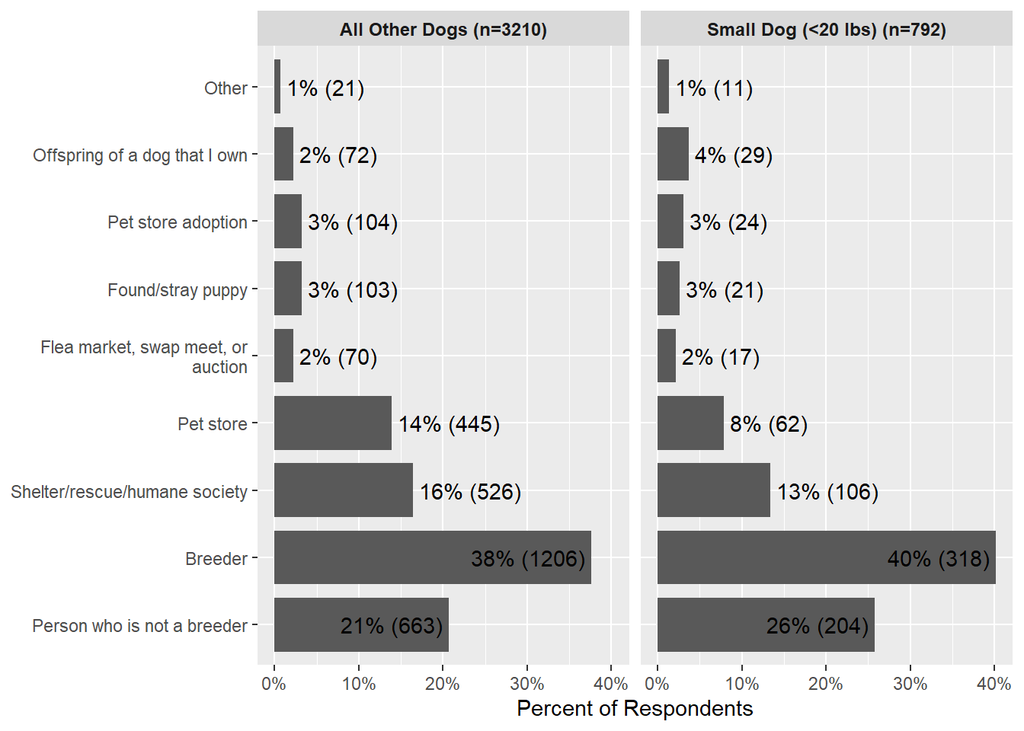

### > Q35 (…)

**Q35: Was this your first choice for where to get your puppy?**

3880 non-empty/NA responses out of 4002 possible responses ( 97 %)

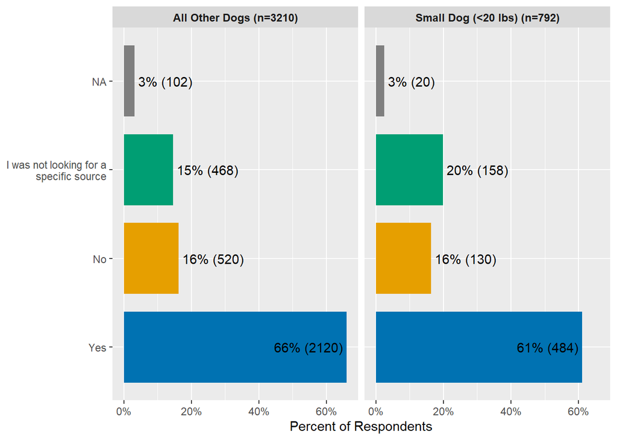

#### >> Q36

**Q36: What was your first choice for where to get your puppy?**

650 non-empty/NA responses out of 650 possible responses ( 100 %)

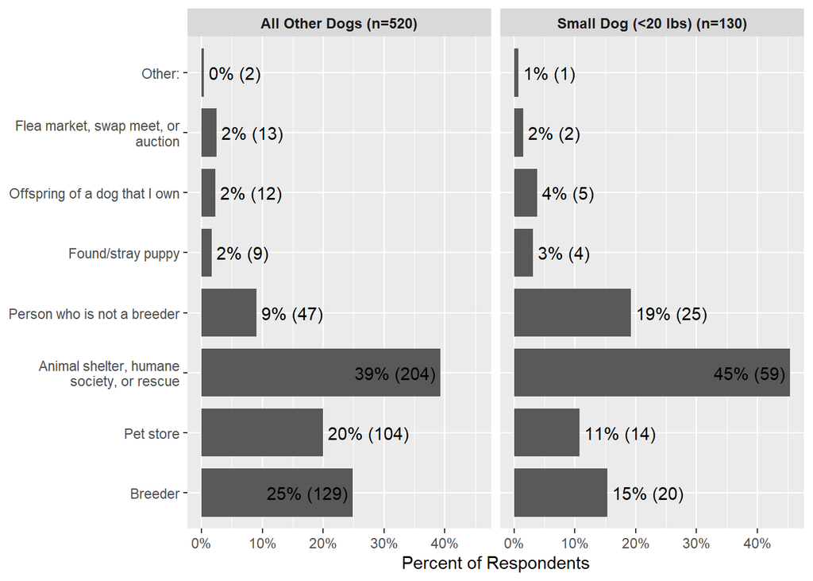

### > Q37

**Q37: How likely are you to recommend the place where you got your puppy to a friend?**

3880 non-empty/NA responses out of 4002 possible responses ( 97 %)

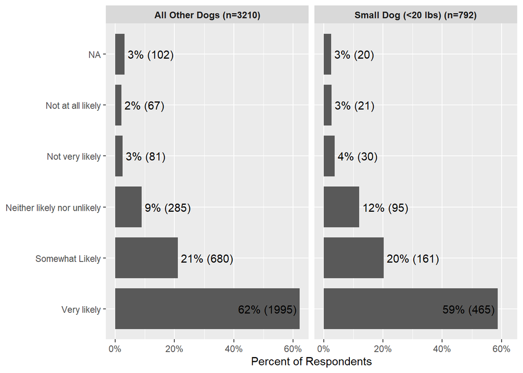

### > Q38

**Q38: If you had not been able to get your puppy, what would you have most likely done?**

3856 non-empty/NA responses out of 4002 possible responses ( 96 %)

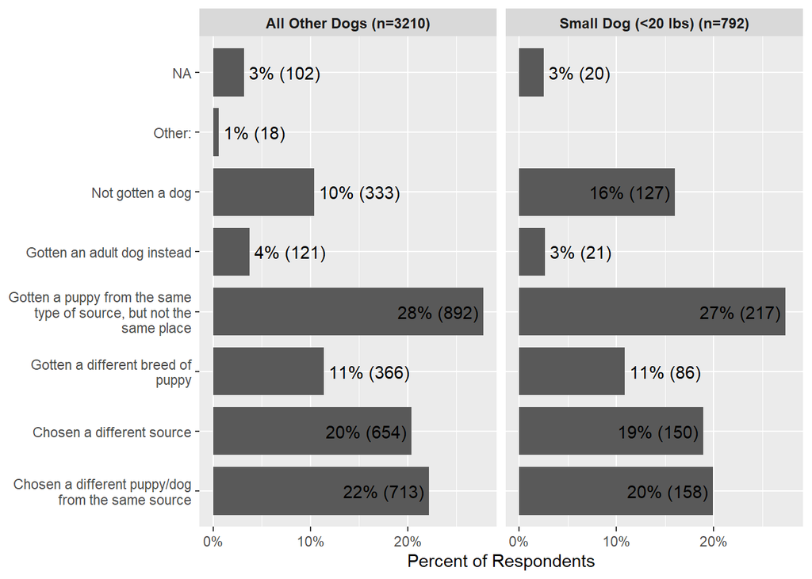

### > Source - breeder

### > Q39

**Q39: What best describes how you found your puppy’s breeder?**

1519 non-empty/NA responses out of 1519 possible responses ( 100 %)

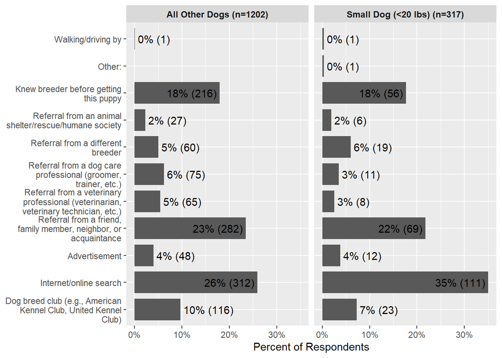

### > Q40

**Did you or someone in your household see your puppy before you brought them home?**

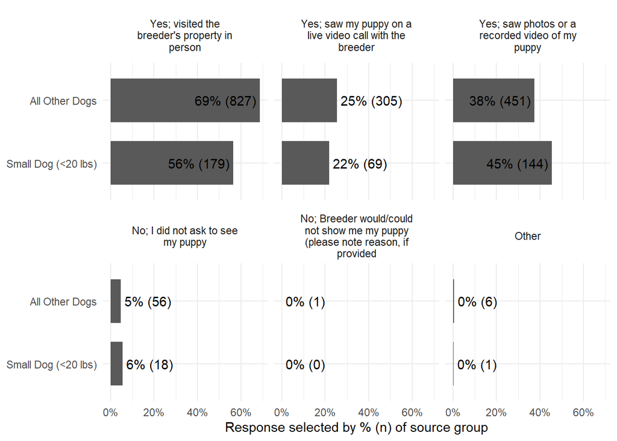

### > Q41

**Did the breeder do any of the following things before you took your puppy home?**

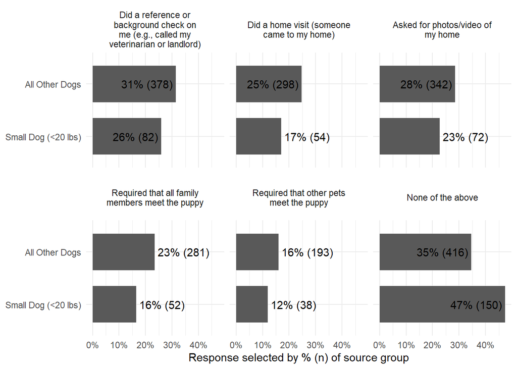

### > Q42

**Q42: Did your breeder have more than one litter of puppies when you got your puppy?**

1519 non-empty/NA responses out of 1519 possible responses ( 100 %)

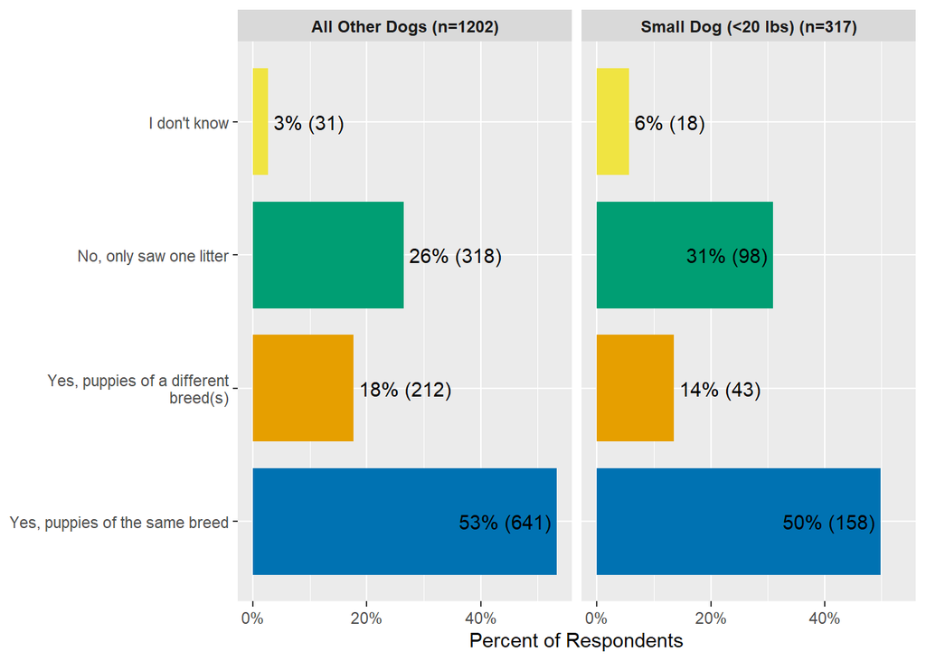

### > Q43

**Q43: Where does your puppy’s breeder live?**

1519 non-empty/NA responses out of 1519 possible responses ( 100 %)

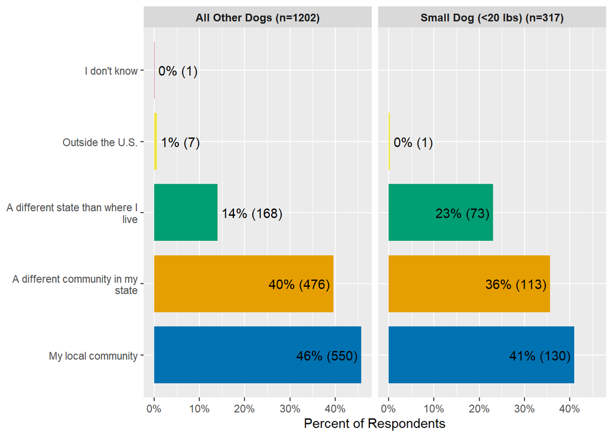

### > Q44 (…)

**Q44: Where did you pick up your puppy to bring them home?**

1519 non-empty/NA responses out of 1519 possible responses ( 100 %)

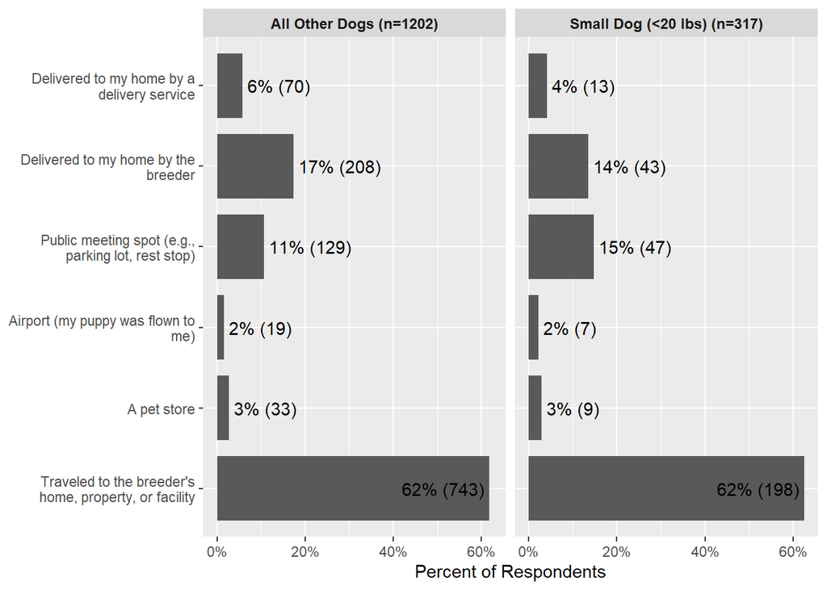

#### >> Q45

**When you picked up your puppy, did you see other dogs at the breeder’s?**

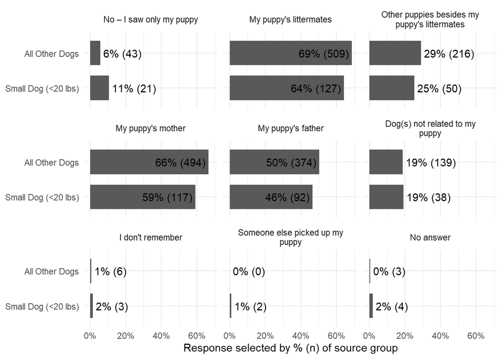

#### >> Q46

**Q46: How far did you travel to pick up your puppy?**

242 non-empty/NA responses out of 244 possible responses ( 99 %)

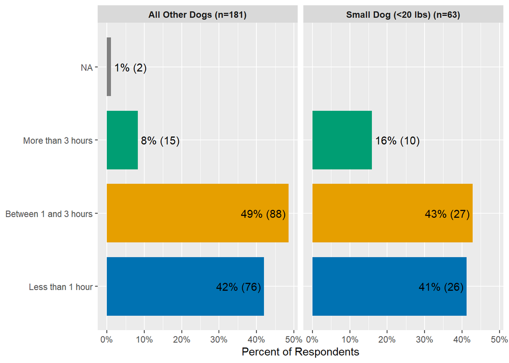

### > Source - pet store

### > Q47

**Q47: Did you buy your puppy directly from the pet store, or from an organization that works with the pet store to find homes for dogs (e.g., a humane society)?**

587 non-empty/NA responses out of 587 possible responses ( 100 %)

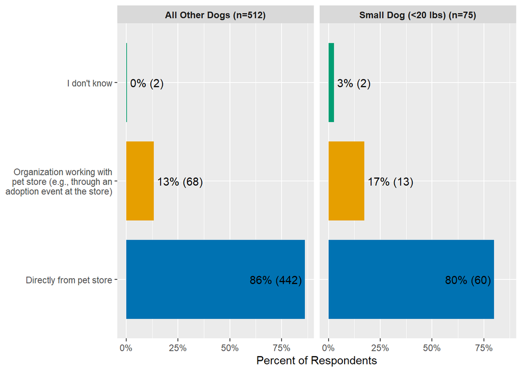

### > Q48

**Q48: What best describes how you found the pet store where you got your puppy?**

587 non-empty/NA responses out of 587 possible responses ( 100 %)

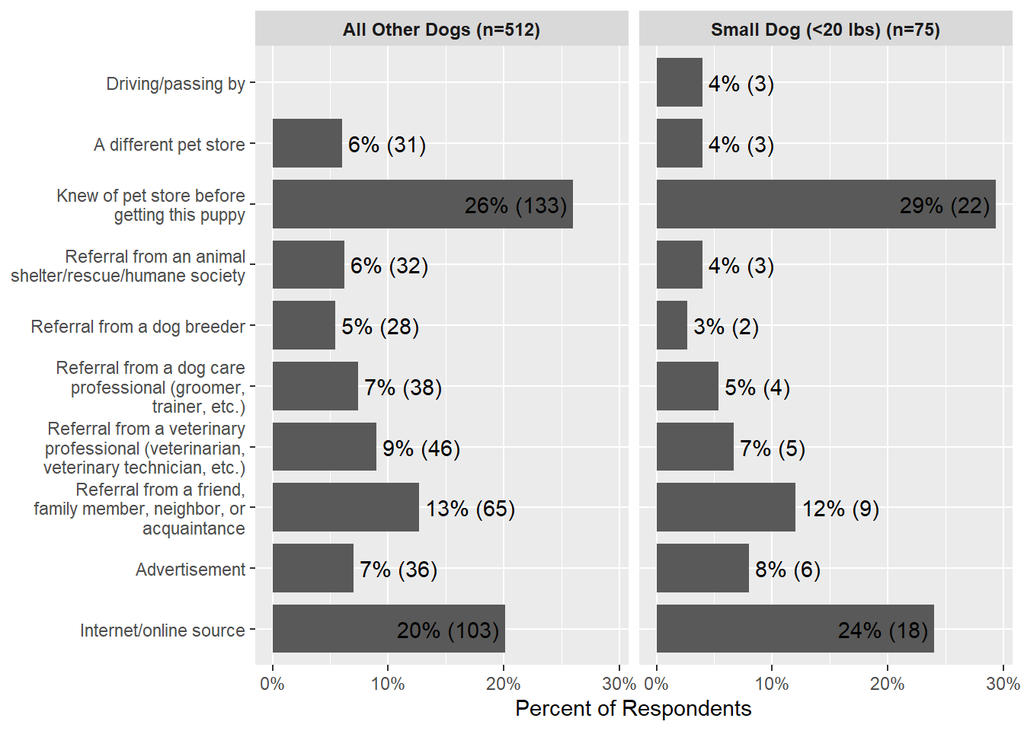

### > Q49

**Q49: Where was your puppy born?**

587 non-empty/NA responses out of 587 possible responses ( 100 %)

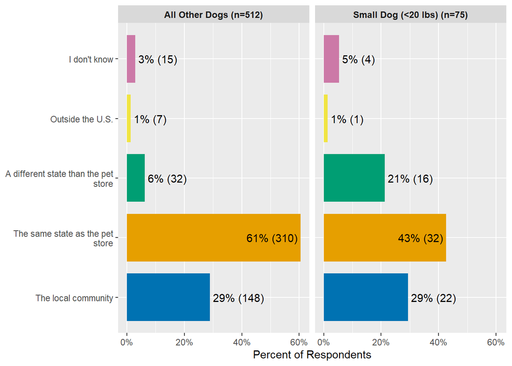

### > Source - person, not breeder

### > Q50 (…)

**Q50: What best describes the person from whom you got your puppy?**

837 non-empty/NA responses out of 837 possible responses ( 100 %)

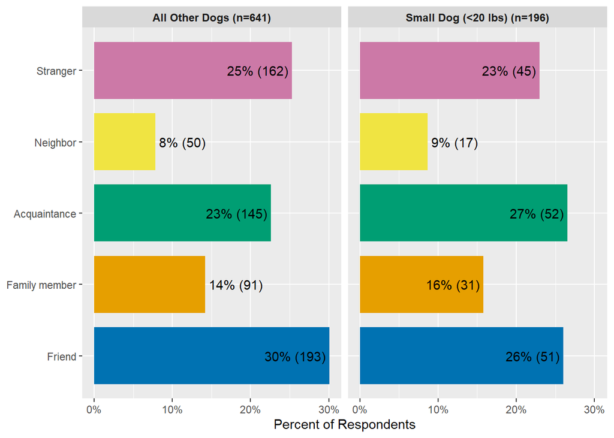

#### >> Q51

**Q51: What best describes how you learned about the puppy being available?**

207 non-empty/NA responses out of 207 possible responses ( 100 %)

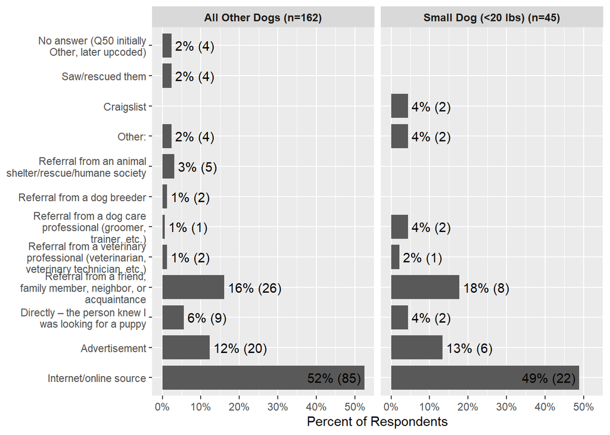

### > Q52

**Did the person do any of the following before you took your puppy home?**

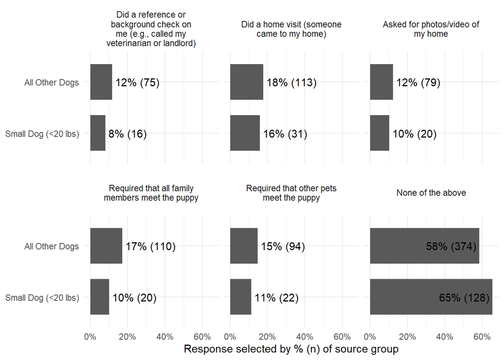

### > Q53

**Q53: Where was your puppy born?**

837 non-empty/NA responses out of 837 possible responses ( 100 %)

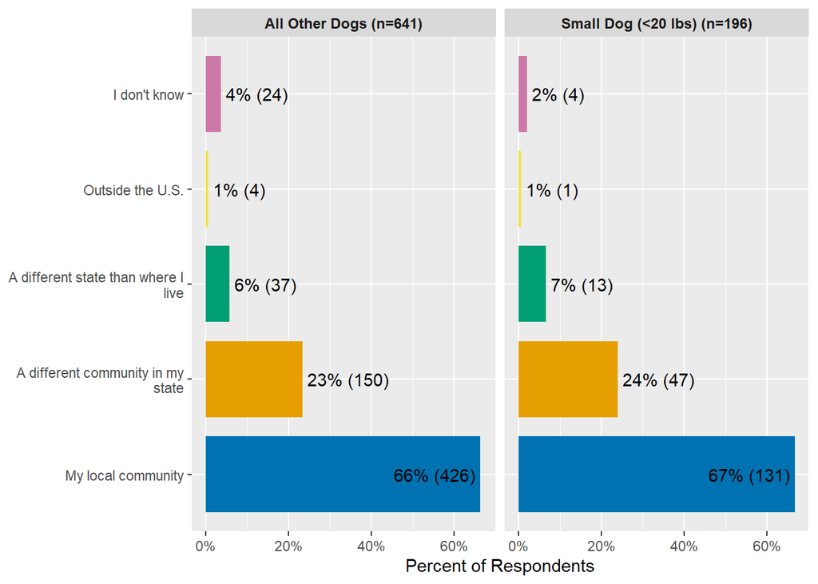

### > Q54 (…)

**Q54: Was your puppy born in this person’s care?**

837 non-empty/NA responses out of 837 possible responses ( 100 %)

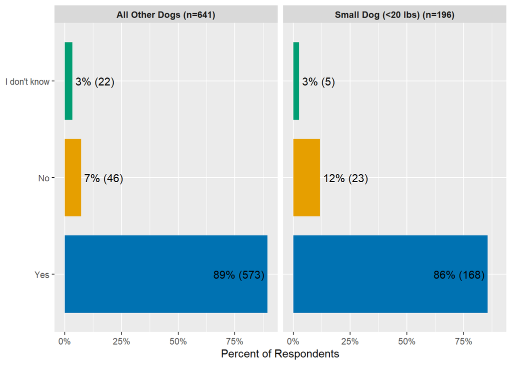

#### >> Q55

**Q55: Was the litter planned (did the person want a litter of puppies)?**

741 non-empty/NA responses out of 741 possible responses ( 100 %)

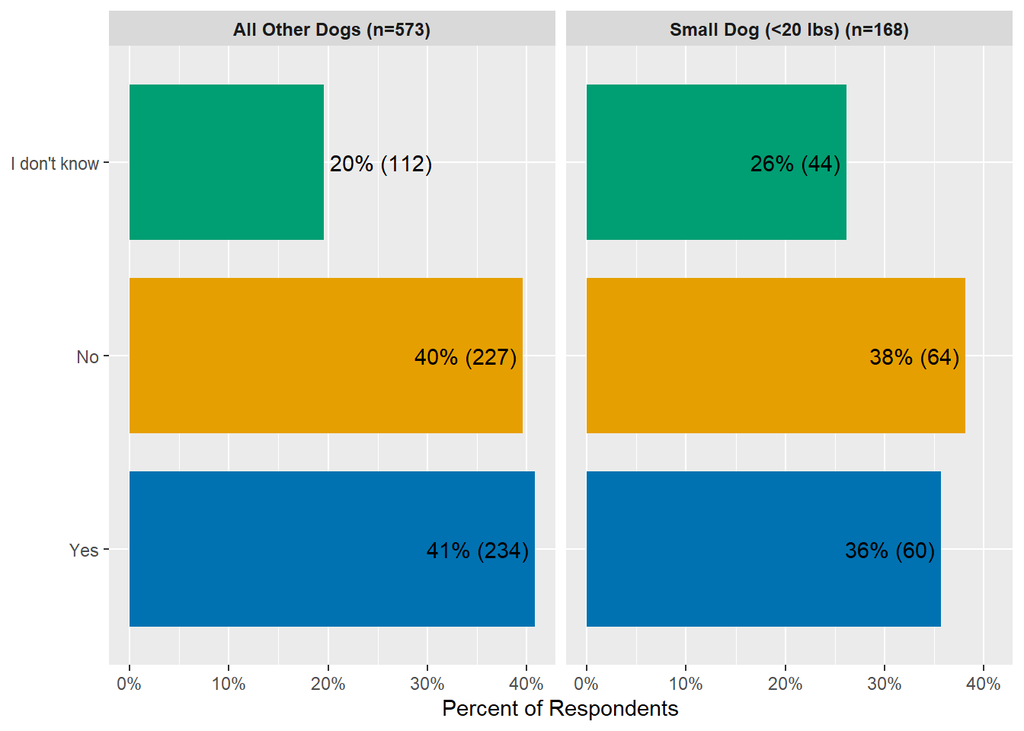

#### >> Q56

**Q56: Where did the person get the puppy?**

69 non-empty/NA responses out of 69 possible responses ( 100 %)

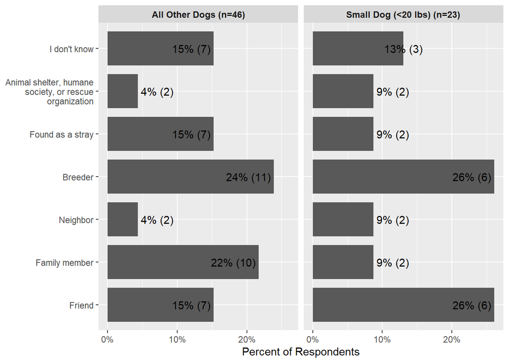

### > Q57

**Did you or someone in your household see your puppy before you brought them home?**

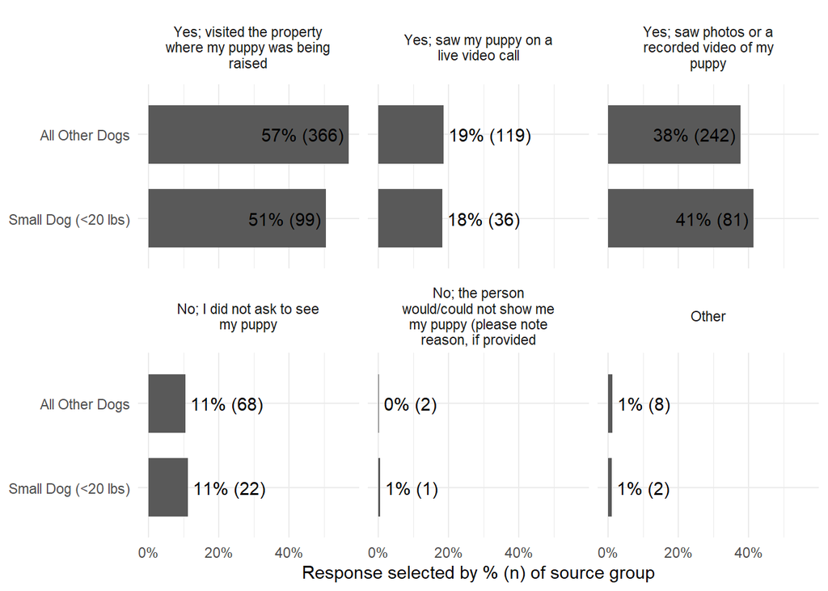

### > Q58

**Q58: Did the person have more than one litter of puppies when you got your puppy?**

837 non-empty/NA responses out of 837 possible responses ( 100 %)

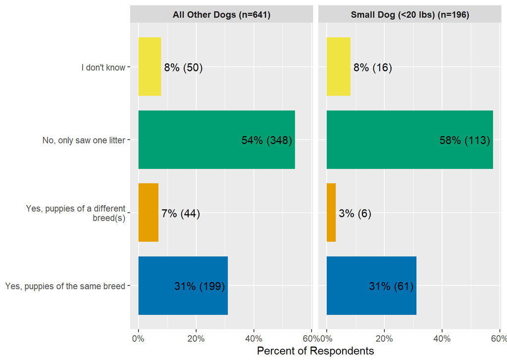

### > Q59 (…)

**Q59: Where did you pick up your puppy to bring them home?**

837 non-empty/NA responses out of 837 possible responses ( 100 %)

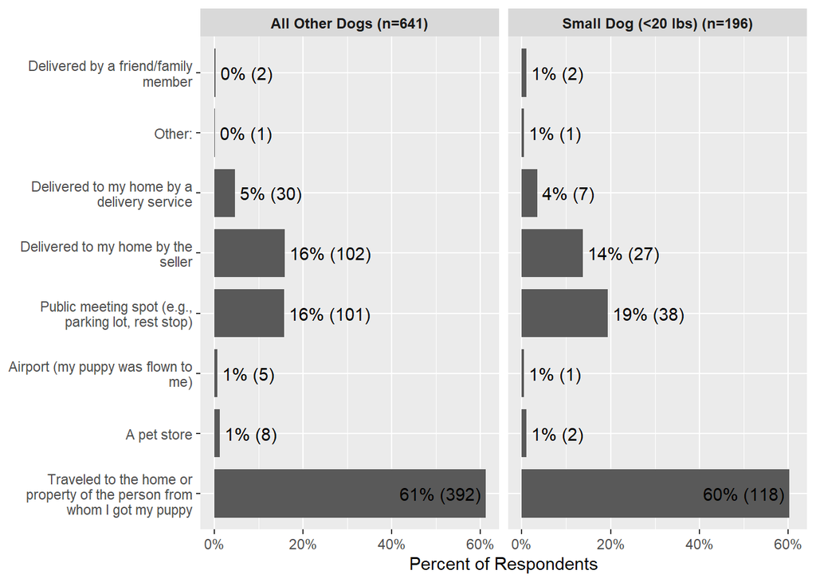

#### >> Q60

**Q60: How far did you travel to pick up your puppy?**

510 non-empty/NA responses out of 510 possible responses ( 100 %)

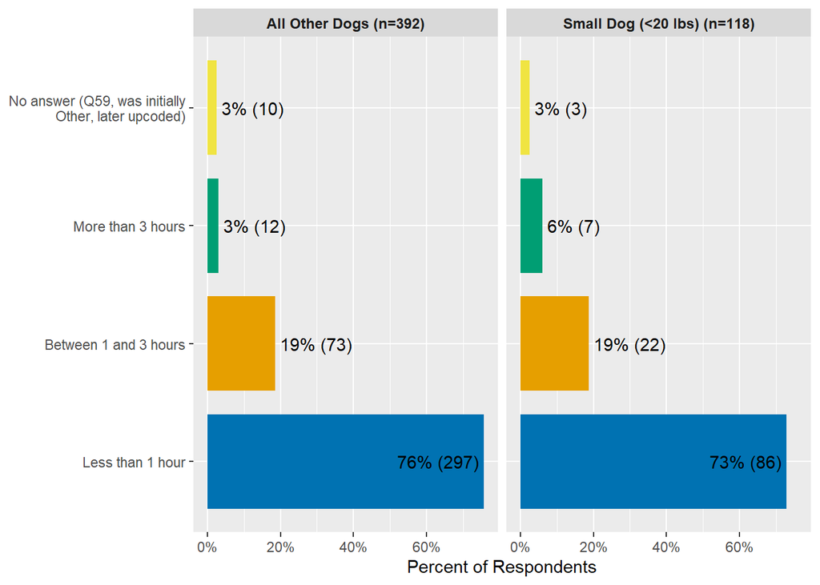

### > Source - shelter/rescue

### > Q61

**To the best of your knowledge, which of the following describe the organization where you got your puppy?**

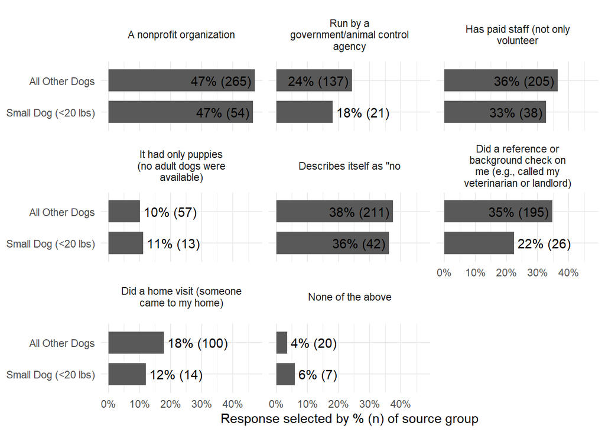

### > Q62

**Where do dogs live at the organization before adoption?**

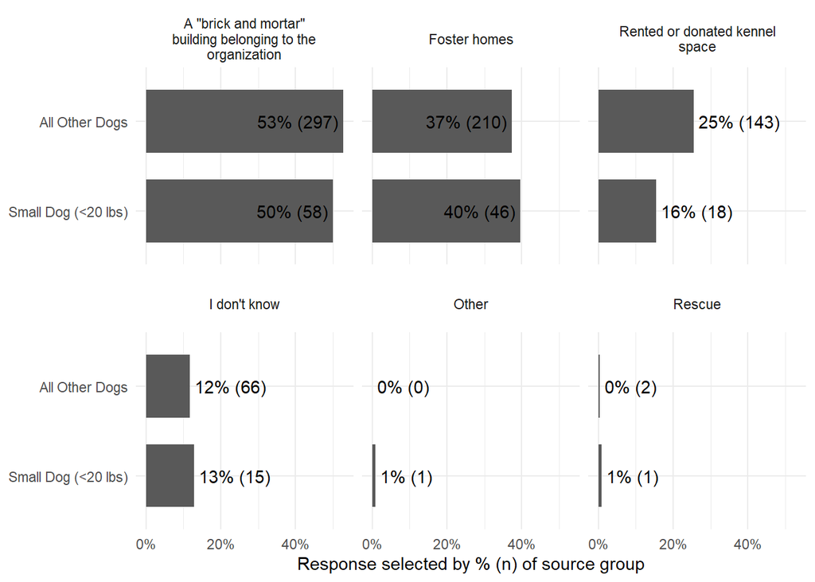

### > Q63

**How did you find the organization from which you got your puppy?**

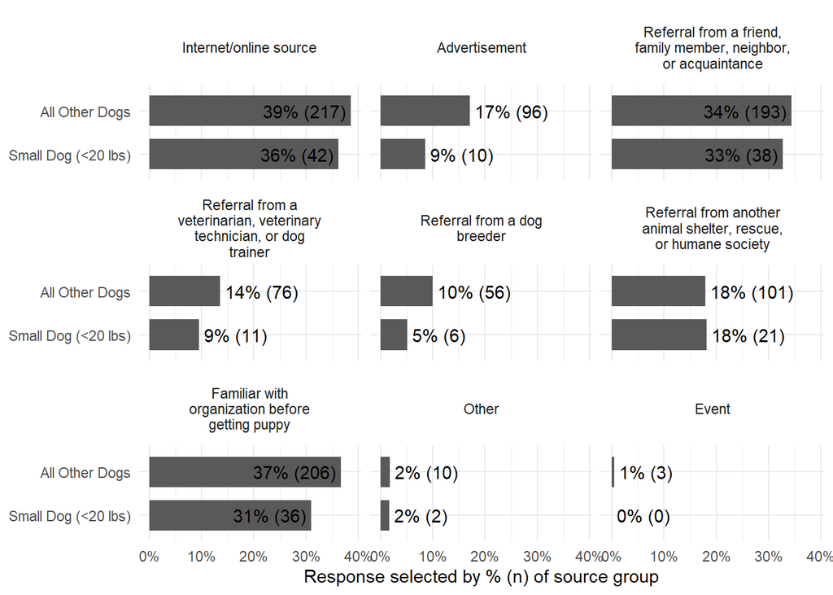

### > Q64

**Q64: What do you know about your puppy’s history?**

678 non-empty/NA responses out of 678 possible responses ( 100 %)

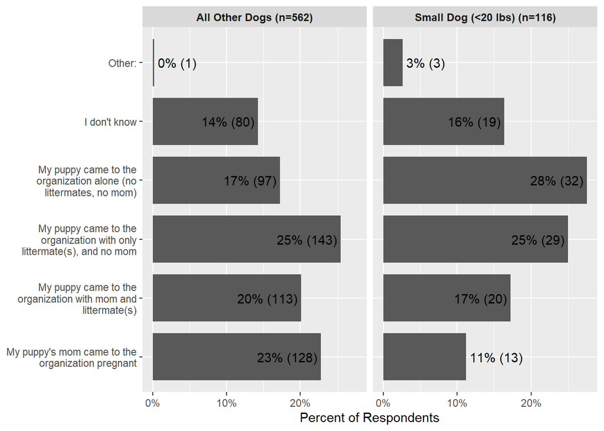

### > Q65

**Q65: Where was your puppy born?**

678 non-empty/NA responses out of 678 possible responses ( 100 %)

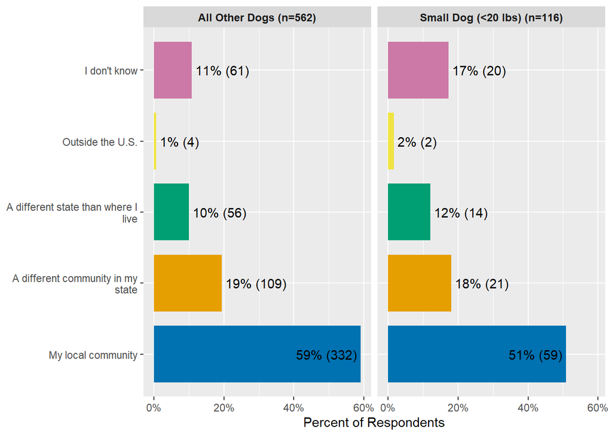

### > Q66 (…)

**Q66: Where did you pick up your puppy to bring them home?**

678 non-empty/NA responses out of 678 possible responses ( 100 %)

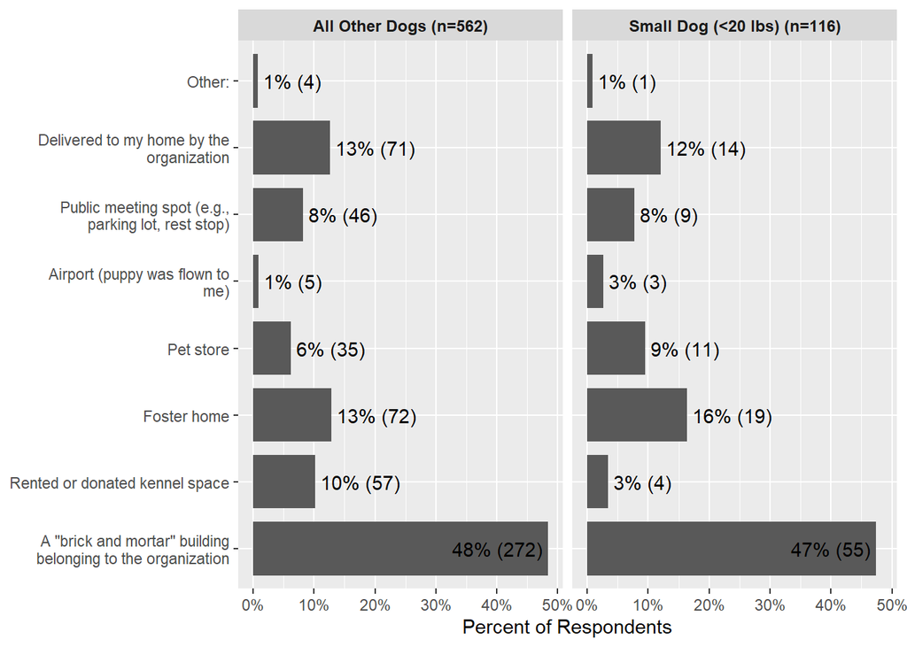

#### >> Q67

**Q67: Was your puppy part of a puppy transport program where you adopted your puppy and then they were brought to you at that location?**

147 non-empty/NA responses out of 148 possible responses ( 99 %)

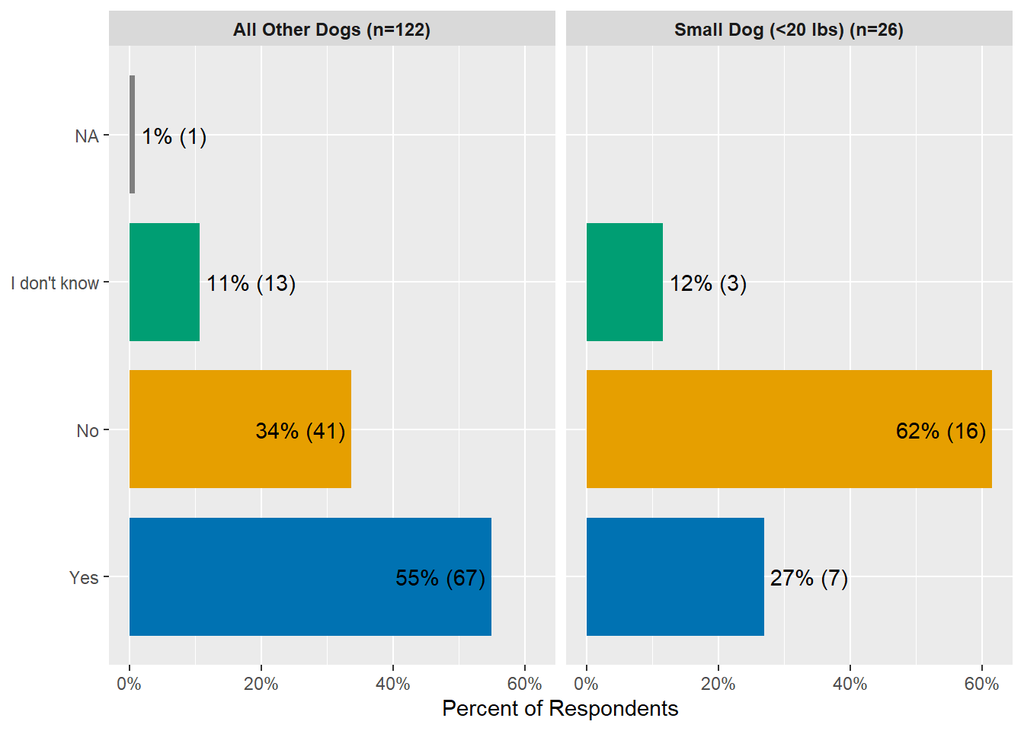

#### >> Q69

**Q69: How far did you travel to pick up your puppy?**

593 non-empty/NA responses out of 593 possible responses ( 100 %)

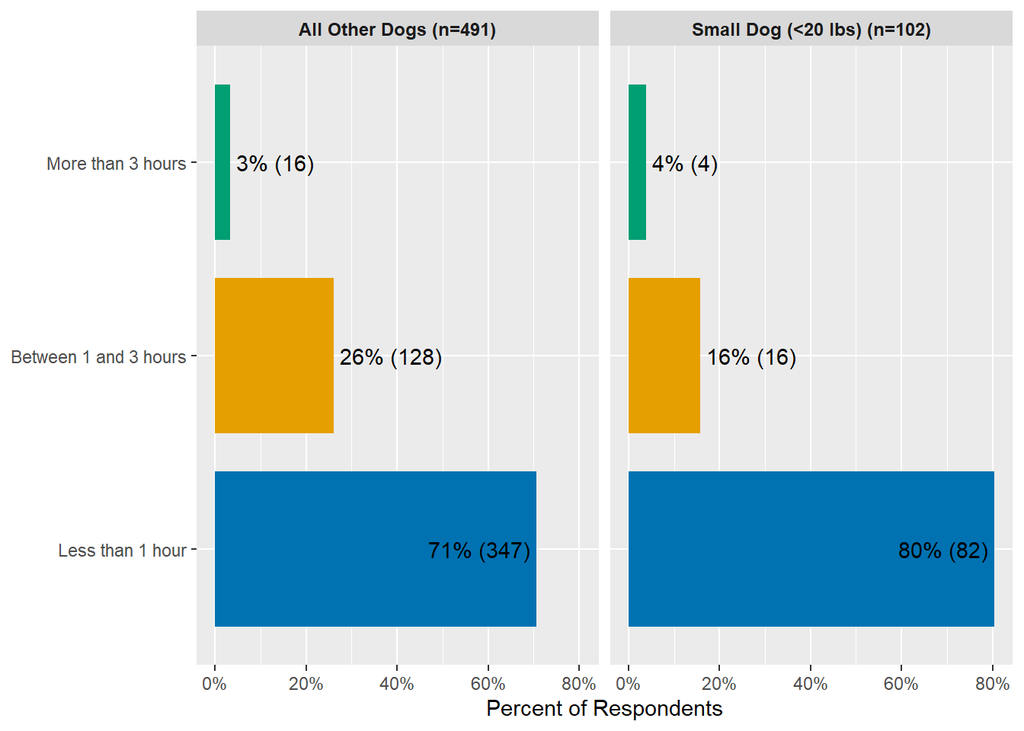

### > Q68

**Q68: Did your puppy live in a foster home (live with a family temporarily) before you adopted them?**

678 non-empty/NA responses out of 678 possible responses ( 100 %)

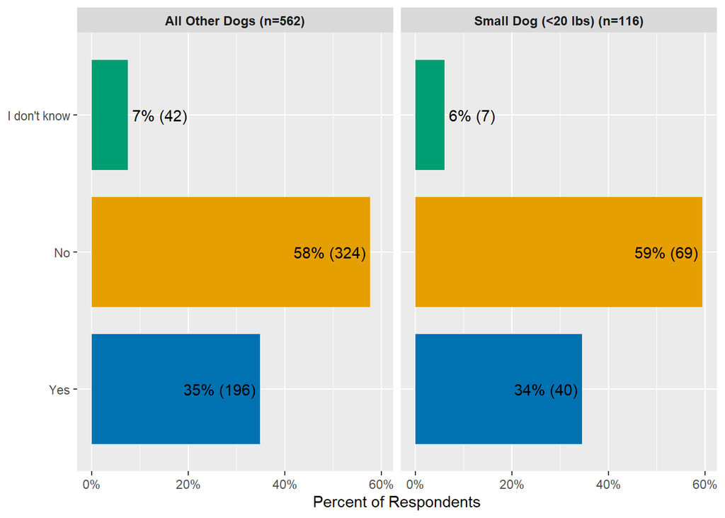

### > Source - found/stray

### > Q70 (…)

**Q70: Did you or someone in your household personally find your stray puppy?**

122 non-empty/NA responses out of 122 possible responses ( 100 %)

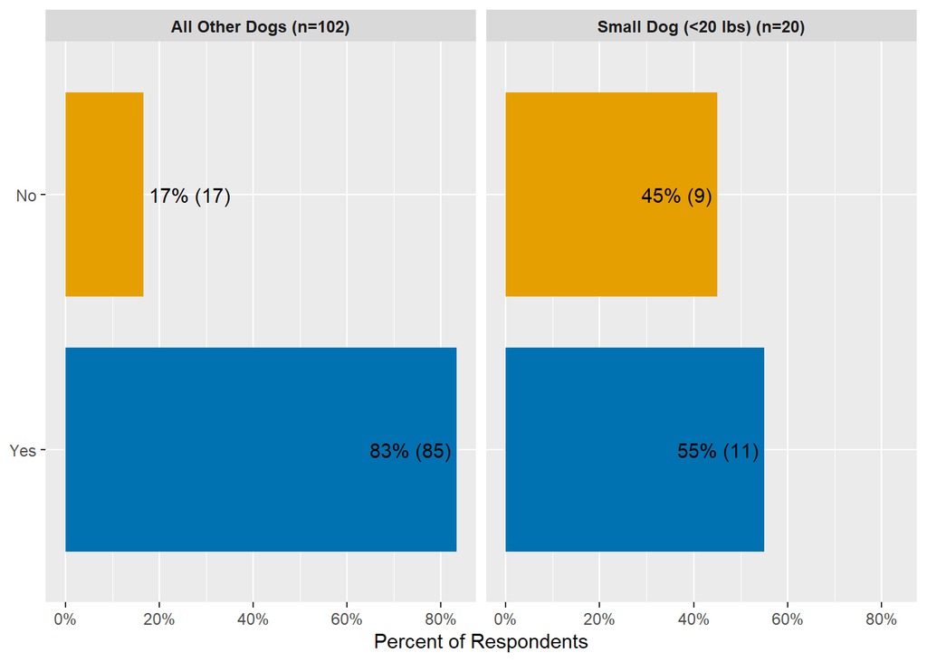

#### >> Q71 (…)

**Q71: What best describes the person from whom you got your puppy?**

26 non-empty/NA responses out of 26 possible responses ( 100 %)

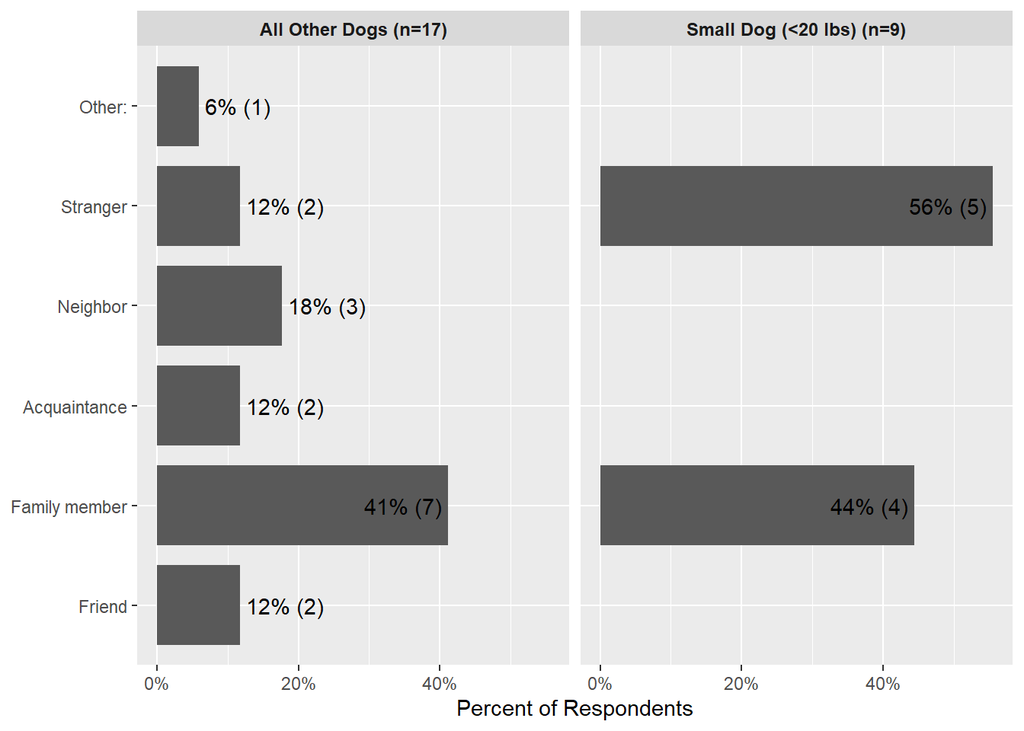

##### >>> Q72

### > Source - offspring

### > Q73 (…)

**Q73: What dogs do you own that are related to your puppy?**

94 non-empty/NA responses out of 94 possible responses ( 100 %)

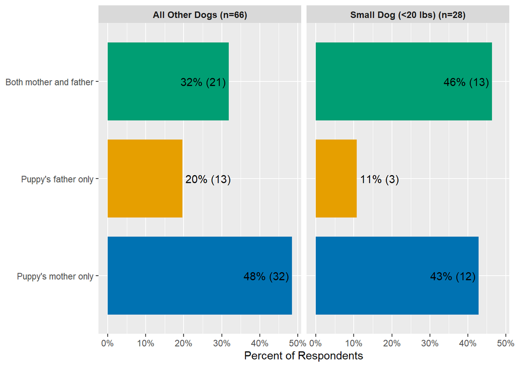

#### >> Q74 (…)

**Q74: Did you plan for your puppy’s mother to have puppies?**

78 non-empty/NA responses out of 78 possible responses ( 100 %)

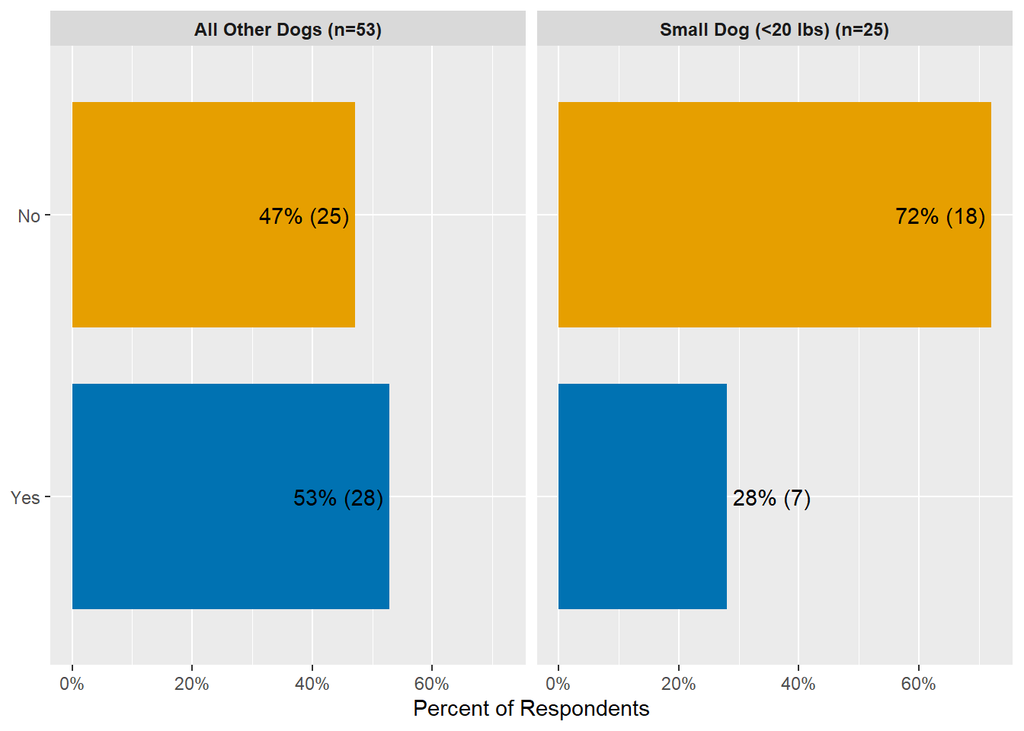

##### >>> Q75 (…)

**Why did you want her to have puppies?**

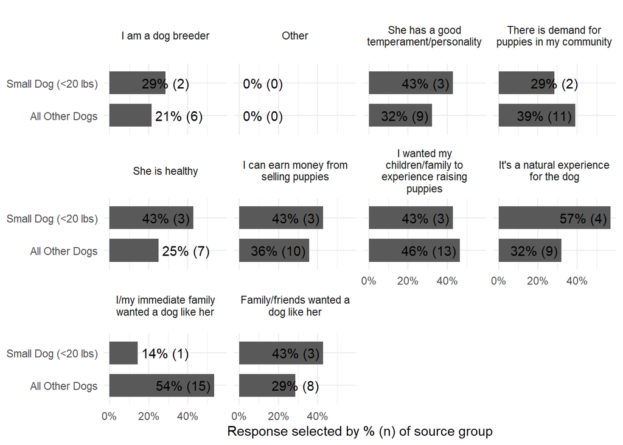

###### >>>> Q76

**Please select all that apply to your goals as a breeder:**

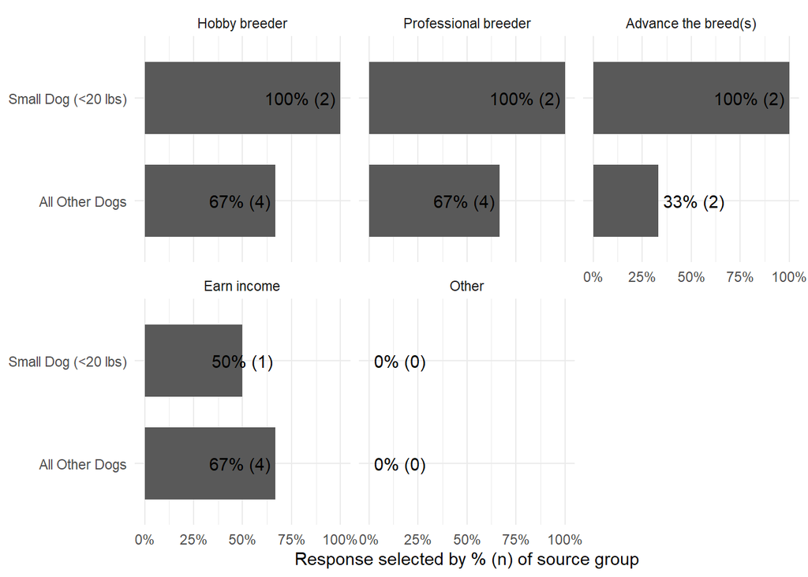

#### >> Q77

**Q77: Do you plan to breed her again?**

78 non-empty/NA responses out of 78 possible responses ( 100 %)

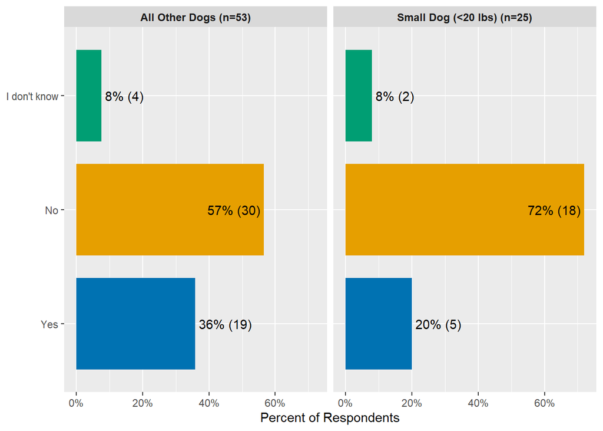

#### >> Q78 (…)

**What happened to her other puppies?**

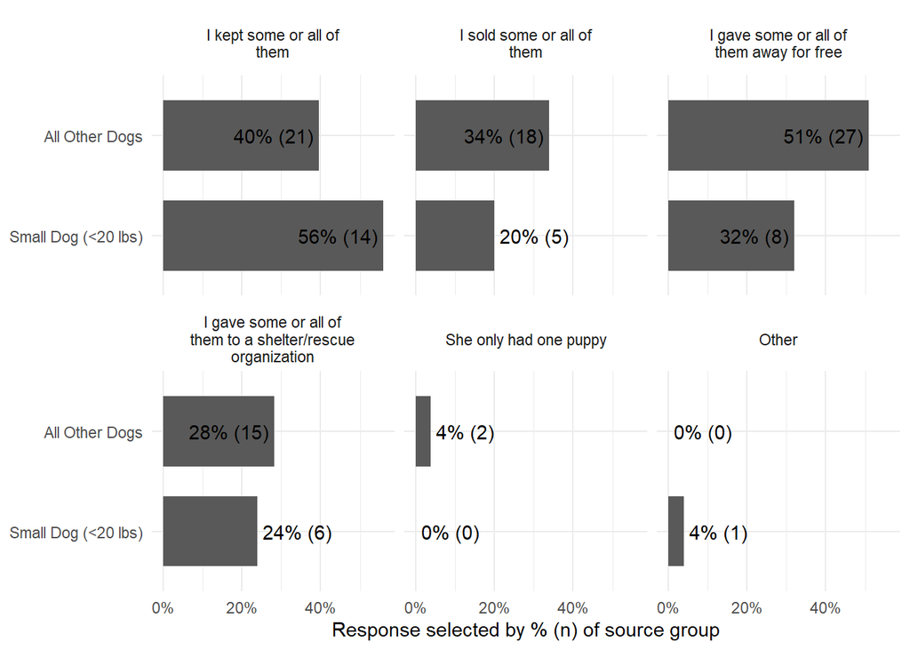

##### >>> Q79

**Where did the other puppies go?**

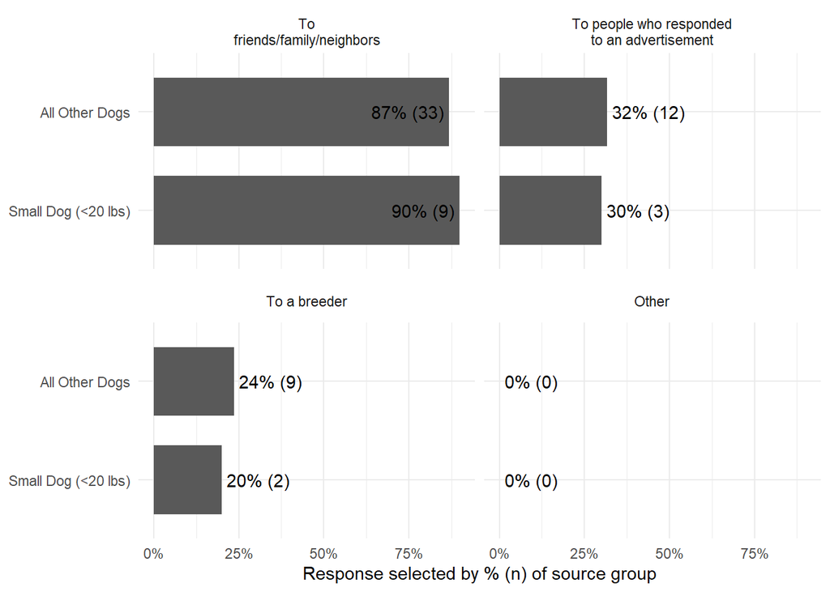

##### >>> Q80

**How old were her puppies when they went to their new homes?**

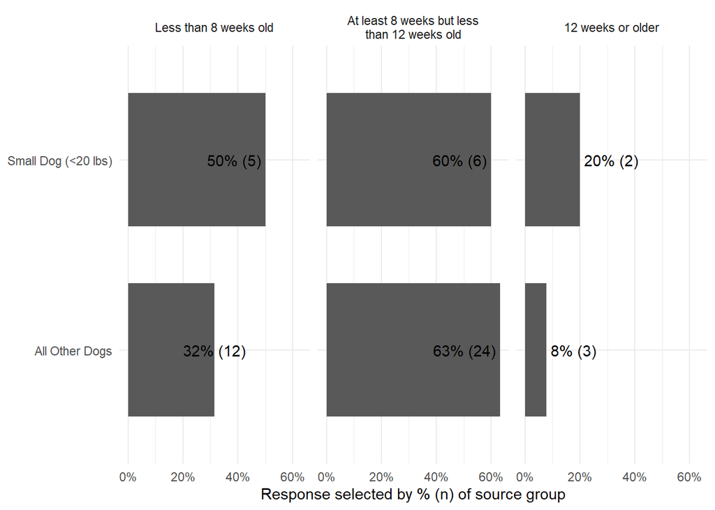